# Masters 8 - Data Visualization for Presentation

Fred LaPolla

7/30/2020

# Pulling in the data

```r
library(RCurl)
url <- getURL("https://raw.githubusercontent.com/fredwillie/RScience2020/master/NYC_HANES_DIAB.csv")
nyc <- read.csv(text = url)
nyc$DX_DBTS <- factor(nyc$DX_DBTS, levels = 1:3, labels = c("Diabetes w/ DX", "Diabetes no DX", "No Diabetes"))
```

# Objectives

Students will be able to:

- Use GGPlot to make publication worthy graphics
- Employ GGPlot’s layering functionality to customize figures
- Use scales and themes to improve layout
- Explain considerations for effective data visualization

# Visualization for Communication

### GGPlot2

A good option is a package called GGPlot2, which stands for Grammar of Graphics (you will never need to know that)

It is part of the tidyverse, so you should actually have it but just in case:

```r
install.packages("ggplot2", repos = "http://cran.us.r-project.org")
library(ggplot2)
```

# GGPlot2

GGPlot is very common, so you should learn it, but it is also kind of weird relative to a lot of ways you might normally think about charts. GGPlot works by assigning values to aesthetic components of a chart (think x, y coordinates, colors, shapes etc), and then adds layers of shapes and labels to actually visualize these things.

This typically requires working in multiple steps.

# GGPlot2 Step1

first we name the dataset and assign our basic X Y coordinates. Not all charts will have both. Let’s start with a basic scatterplot

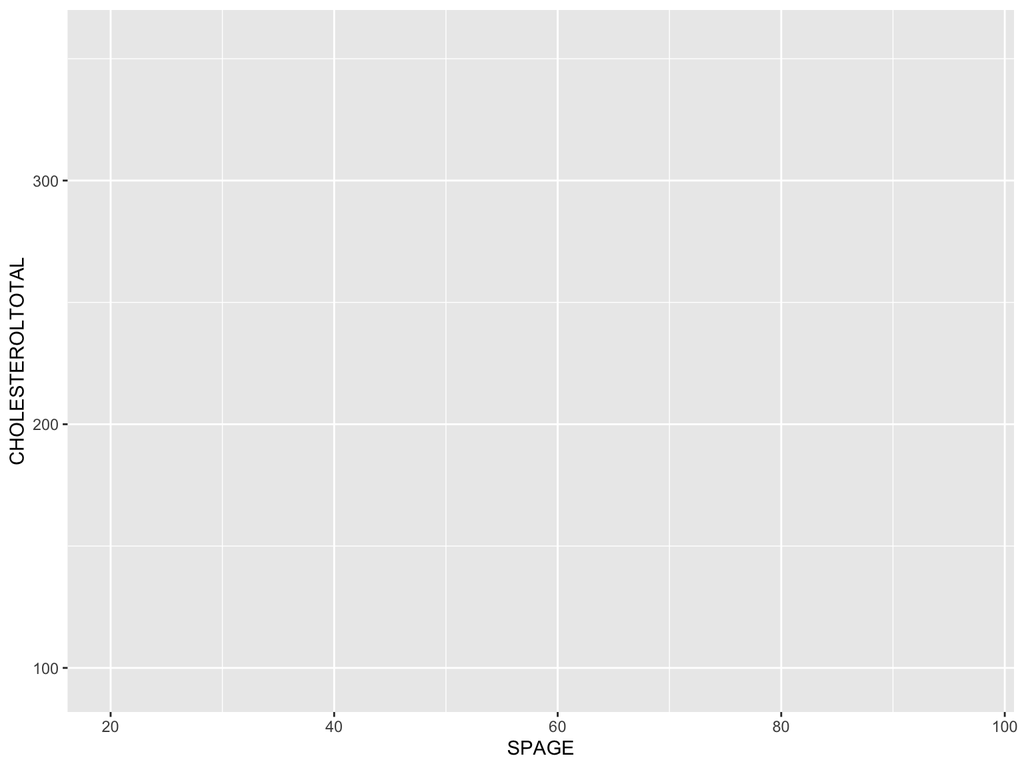

```r
pic <- ggplot(nyc, aes(x = SPAGE, y = CHOLESTEROLTOTAL))
pic
```

When we run this, nothing happens, or seems to happen.

# GGPlot2 Step 2

We next need to add a layer that tells R what sort of shape to map those aesthetic attributes onto:

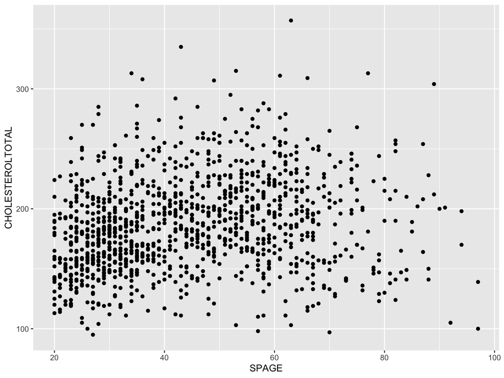

```r
pic + geom_point()
```

# Group Work

Try out using GGplot to make a scatter plot of A1C vs Glucose. Remember there will be two parts: where you assign the aes and then where you add a geom

# A different Geom

We could try a different “geom” but most do not actually make a lot of sense for this combination of variables:

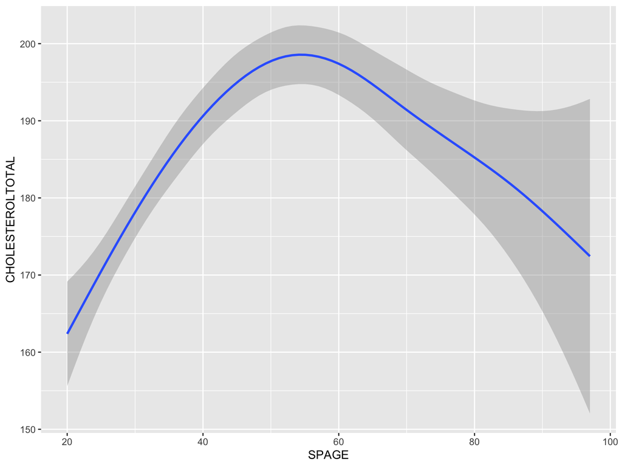

```r
pic + geom_smooth()
```

We can also combine as layers and add a linear estimate with:

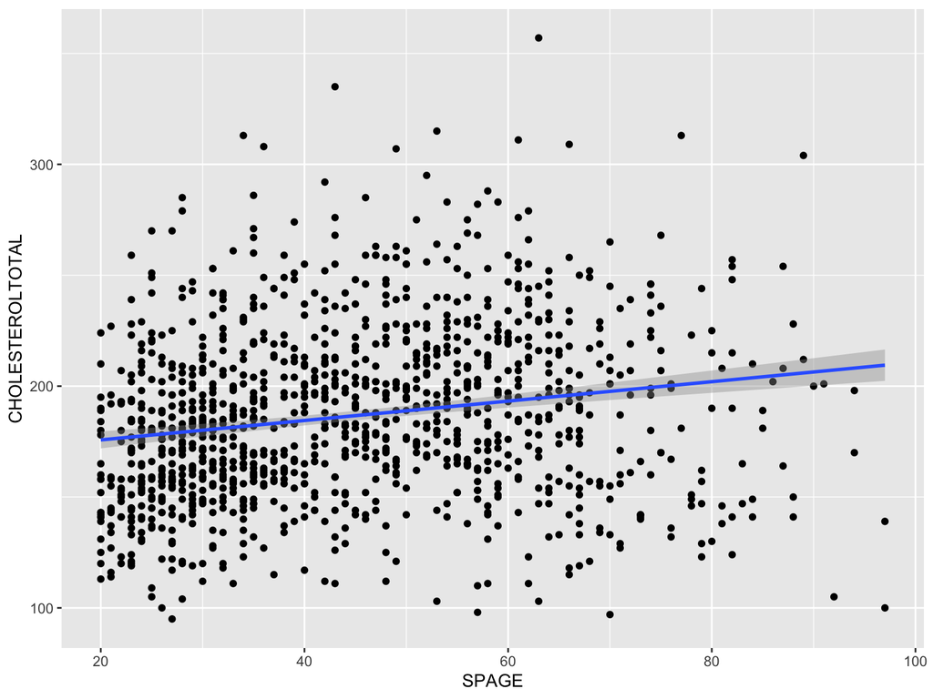

```r
pic + geom_point()+ geom_smooth(method = "lm")
```

There is **no need* to memorize these “geoms.” Instead go to the Help up on the top menu and open the Cheatsheets. There are many cheatsheets, and they add when you install packages. This is a quick reference guide.

# Group work

Try making the same A1C vs Glucose scatter plot but add in a line estimating linear correlation:

# GGPlot 2 Making Histograms and Boxplots

Histograms

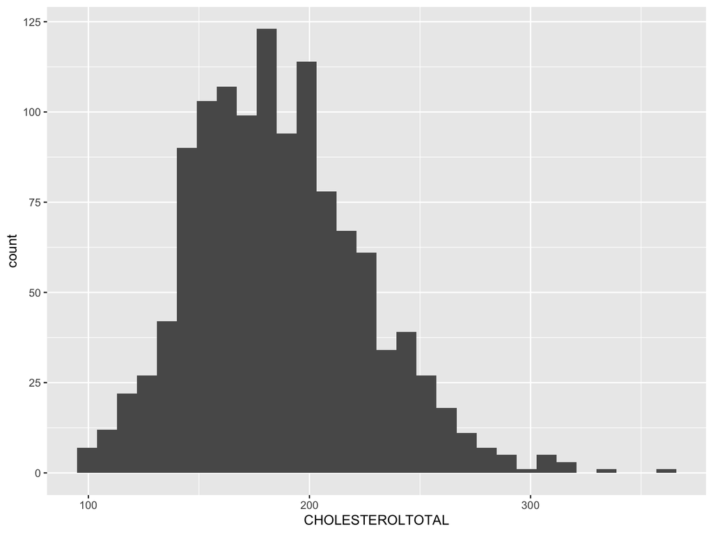

```r
ggplot(nyc, aes(x = CHOLESTEROLTOTAL)) +geom_histogram()
```

# Histogram Bins

We can also set the width

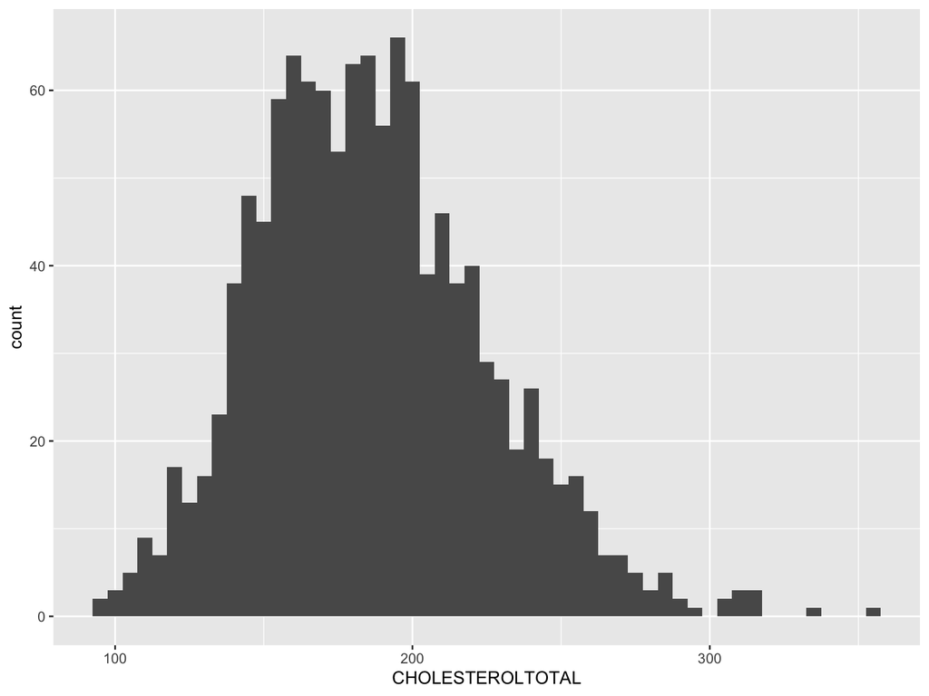

```r
ggplot(nyc, aes(x = CHOLESTEROLTOTAL, )) +geom_histogram(binwidth=5)
```

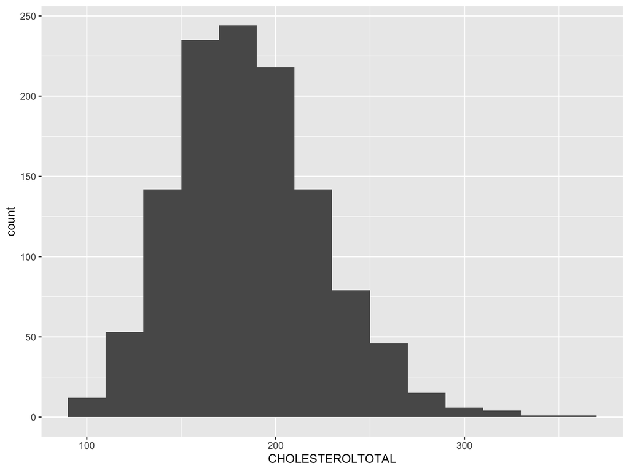

```r
ggplot(nyc, aes(x = CHOLESTEROLTOTAL,)) +geom_histogram(binwidth=20)
```

Or

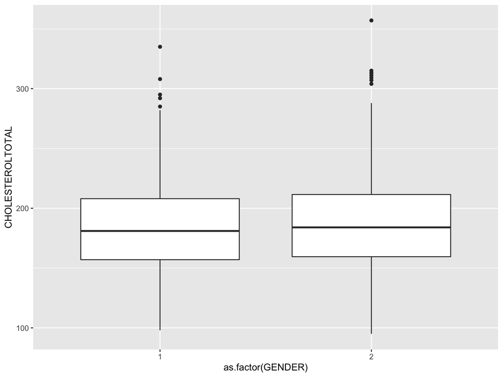

```r
ggplot(nyc, aes(x = as.factor(GENDER), y =CHOLESTEROLTOTAL ))+geom_boxplot()
```

# Group work

Make a histogram of lead levels, experiment with updating the bin width. Make a boxplot of diabetes diagnosis vs glucose level.

# Error Bars

We can use a layer called stat_summary to add visualizations that are not derived from raw counts, like mean values or confidence intervals:

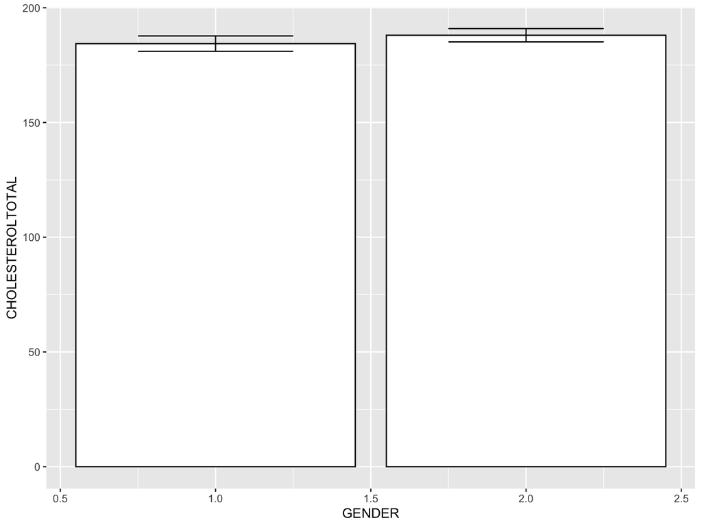

```r
ggplot(nyc, aes(x = GENDER, y = CHOLESTEROLTOTAL)) + stat_summary(fun = mean, geom="bar",fill = "white", color = "black") + stat_summary(fun.data = mean_cl_normal, geom = "errorbar", width = .5)
```

# Group Work

Try making an error bar for mean Glucose by diabetes diagnosis

# GGPlot for formatting

So far we have just found a relatively complex way to make the same plots that hist() and boxplot() made.

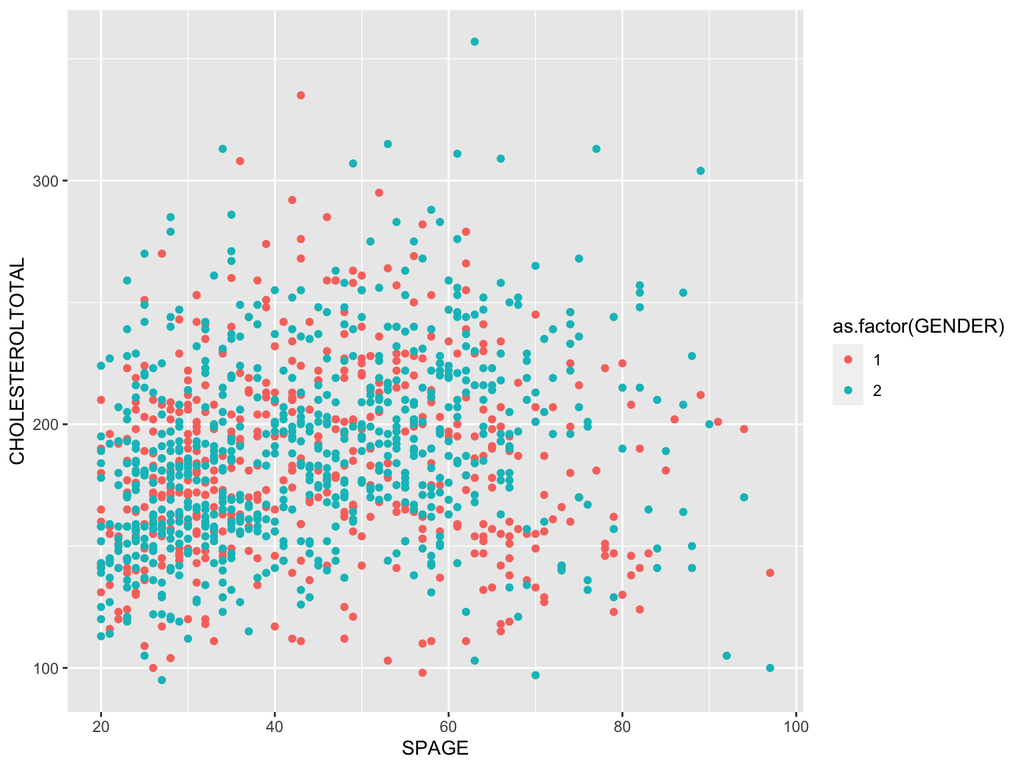

```r
ggplot(nyc, aes(x = SPAGE, y = CHOLESTEROLTOTAL, col = as.factor(GENDER)))+geom_point()
```

# Color continued

A quirk of ggplot is that colors of points are encoded col, but if you want bars to be filled, you must use fill:

[figure not shown]

```r
ggplot(nyc, aes(x = CHOLESTEROLTOTAL, y = ..count.., fill = GENDER)) +geom_bar(width = 10)
```

# Color Palettes

You can also use color blind friendly palettes, like those offered by the package colorbrewer2

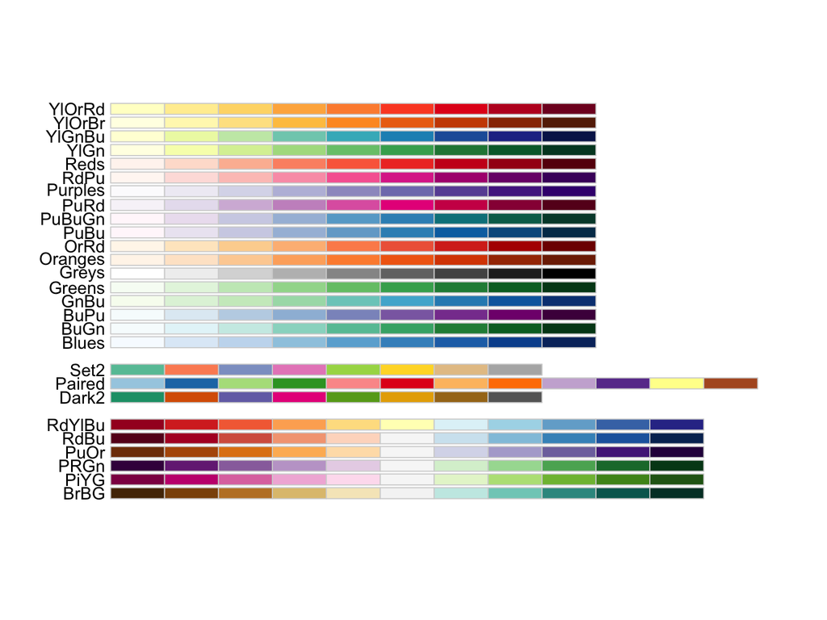

```r
install.packages("RColorBrewer", repos = "http://cran.us.r-project.org")
library(RColorBrewer)
display.brewer.all(colorblindFriendly = TRUE)
```

Then:

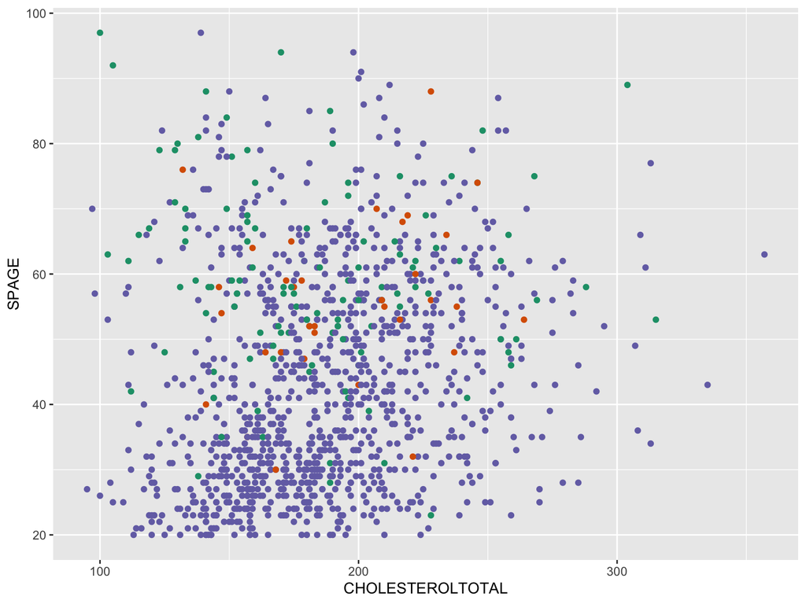

```r
ggplot(nyc, aes(x = CHOLESTEROLTOTAL, y = SPAGE, col = DX_DBTS))+geom_point() + scale_color_brewer(breaks = 3,palette = "Dark2")
```

# Group Work

Explore the palettes on R color brewer. Try changing the color scale on a scatter plot of glucose vs. A1C

# Scales

We may also want to change up the scales. The plot we just made aonly had tick marks every 100, but that is too large a scale for cholesterol. the seq() command takes in a starting value, a finishing value and a number to count by.

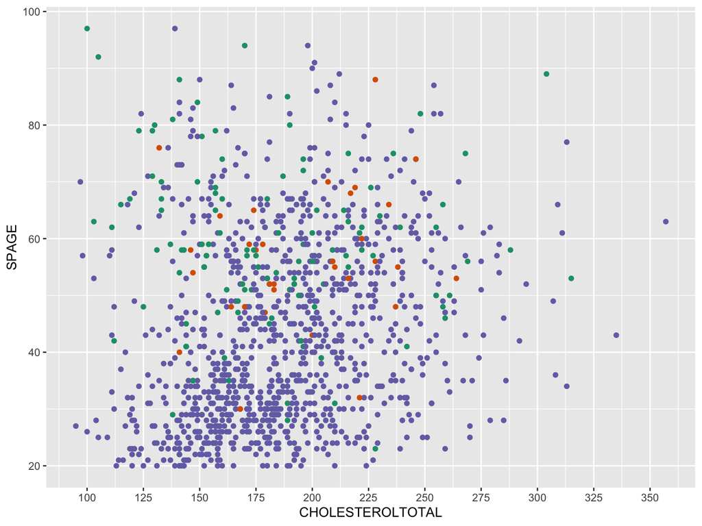

```r
ggplot(nyc, aes(x = CHOLESTEROLTOTAL, y = SPAGE, col =DX_DBTS))+geom_point()+ scale_color_brewer(breaks = 3,palette = "Dark2")  + scale_x_continuous(breaks = seq(0, 400, 25))
```

We could do the same for the y scale:

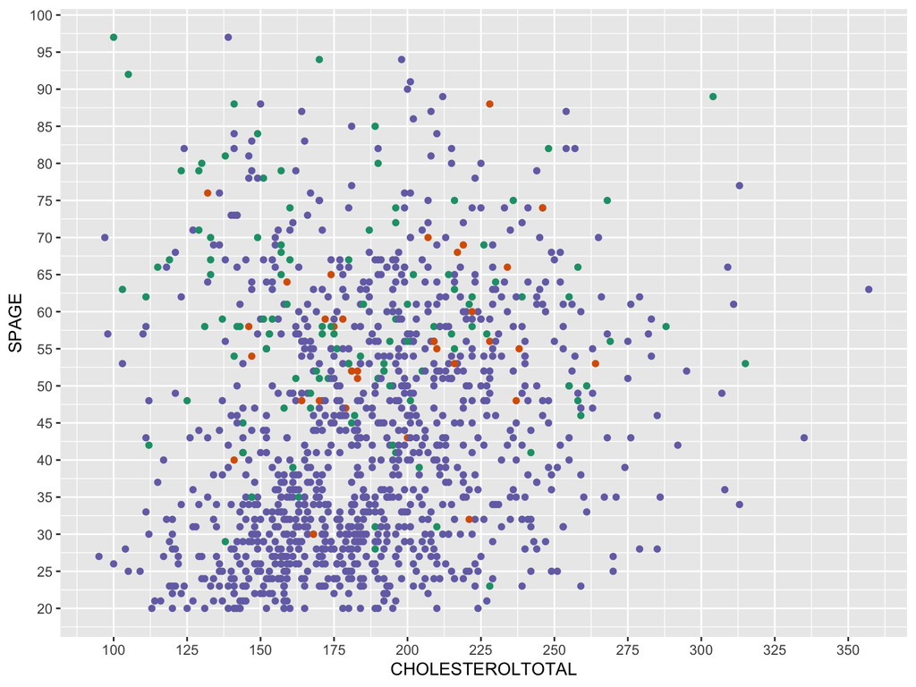

```r
ggplot(nyc, aes(x = CHOLESTEROLTOTAL, y = SPAGE, col = DX_DBTS))+geom_point() +scale_color_brewer(breaks = 3,palette = "Dark2") + scale_x_continuous(breaks = seq(0, 400, 25))+scale_y_continuous(breaks = seq(0, 100, 5))
```

# Labels

We can also relabel the labels to make it more presentable for a paper, poster or talk. Perhaps you are noticing a trend that at first seems strange in ggplot but makes life easier: we keep making changes by adding arguments on to the end. This means once you get your baseline plot drawn you can then experiment on customizing for publication.

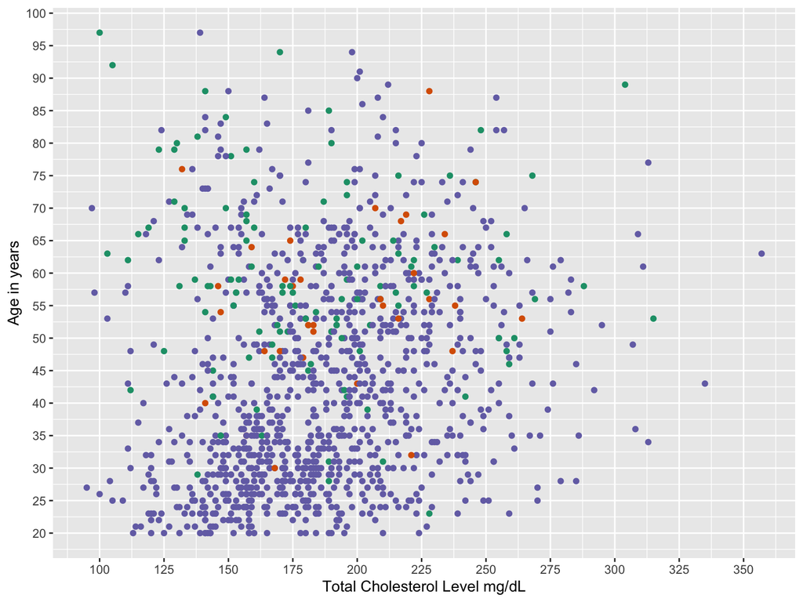

```r
ggplot(nyc, aes(x = CHOLESTEROLTOTAL, y = SPAGE, col = DX_DBTS))+geom_point() +scale_color_brewer(breaks = 3,palette = "Dark2") + scale_x_continuous(breaks = seq(0, 400, 25))+scale_y_continuous(breaks = seq(0, 100, 5)) + xlab("Total Cholesterol Level mg/dL") + ylab("Age in years")
```

# Themes

We can also customize the overall “look” of the chart with a theme. As you start adding “theme_” R will suggest options, try them out to see which you like. The second theme argument removes a redundant label on the legend.

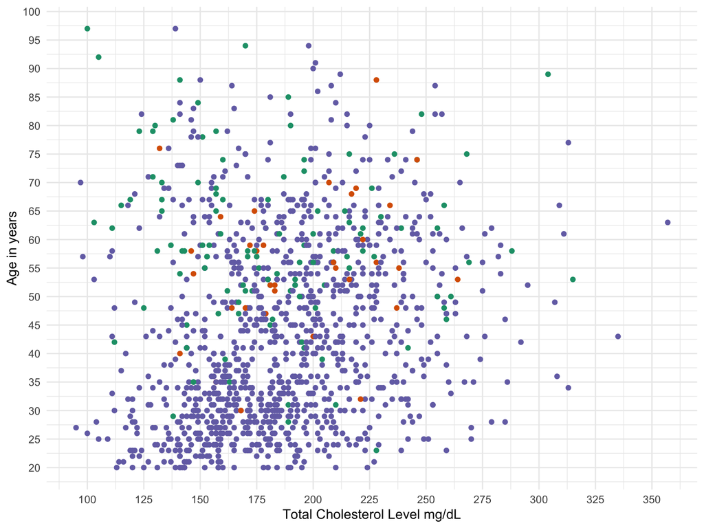

```r
ggplot(nyc, aes(x = CHOLESTEROLTOTAL, y = SPAGE, col = DX_DBTS))+geom_point()+scale_color_brewer(breaks = 3,palette = "Dark2")  + scale_x_continuous(breaks = seq(0, 400, 25))+scale_y_continuous(breaks = seq(0, 100, 5)) + xlab("Total Cholesterol Level mg/dL") + ylab("Age in years") + theme_minimal() + theme(legend.title = element_blank())
```

# Group work

Try adjusting the X and Y scales to be in increments of 50 for glucose, 2 for A1C in your scatter plot of A1C vs Glucose. Change the theme (background), update the X and Y labels to say “A1C level” and “Glucose level”.

# Things to consider when choosing colors and themes

- Accessibility (color blind friendly palettes can help).
- Where will this be seen? Large rooms like conference plenaries, might benefit from a dark background with light points, bright rooms with slide projectors will benefit from light backgrounds and dark points.
- Posters assume that readers have limited time and need a simple message.
- In journal papers provide enough information that a user can understand without flipping to additional information.
- Avoid gimmicks like 3D designs.